# Project one: Lending Club Data Analysis

Uyemaa Gantulga

10/15/2024

### Setting up

```r
knitr::opts_chunk$set(echo = TRUE, include = TRUE)
library(knitr)
library(dplyr)
```

```r
library(ggplot2)
library(kableExtra)
library(stats)
```

### Load data - See what is in the dataset

```r
accepted_loans <- read.csv("C:\\Users\\uemaa\\Documents\\Data Science\\Project 1\\cleaned_accepted_2013_to_2018Q4.csv")
rejected_loans <- read.csv("C:\\Users\\uemaa\\Documents\\Data Science\\Project 1\\cleaned_rejected_2013_to_2018Q4.csv")
```

#Data cleaning see what are in the

```r
unique(rejected_loans$emp_length)
```

[output not shown]

```r
unique(accepted_loans$employement.length)
```

[output not shown]

#Data cleaning, bringing the numbers to numeric value in employment length data

```r
# copy of the Employment.Length column for rejected loans and emp_length for accepted loans
rejected_loans$emp_length_cleaned <- rejected_loans$Employment.Length
accepted_loans$emp_length_cleaned <- accepted_loans$emp_length

# Replace "< 1 year" with 0.5, "10+ years" with 10, and remove "years"
rejected_loans$emp_length_cleaned <- gsub("< 1", "0.5", rejected_loans$emp_length_cleaned)
rejected_loans$emp_length_cleaned <- gsub("10\\+ years", "10", rejected_loans$emp_length_cleaned)
rejected_loans$emp_length_cleaned <- gsub(" years", "", rejected_loans$emp_length_cleaned)

accepted_loans$emp_length_cleaned <- gsub("< 1", "0.5", accepted_loans$emp_length_cleaned)
accepted_loans$emp_length_cleaned <- gsub("10\\+ years", "10", accepted_loans$emp_length_cleaned)
accepted_loans$emp_length_cleaned <- gsub(" years", "", accepted_loans$emp_length_cleaned)

# Convert to numeric
rejected_loans$emp_length_cleaned <- as.numeric(rejected_loans$emp_length_cleaned)
accepted_loans$emp_length_cleaned <- as.numeric(accepted_loans$emp_length_cleaned)
# Result check
summary(rejected_loans$emp_length_cleaned)
```

```
##     Min.  1st Qu.   Median     Mean  3rd Qu.     Max.     NA's
##        2        5        5        5        5       10 23605005
```

```r
summary(accepted_loans$emp_length_cleaned)
```

```
##    Min. 1st Qu.  Median    Mean 3rd Qu.    Max.    NA's
##       2       4       8       7      10      10  464730
```

# Data cleaning, understanding the amount requested column value

```r
# Cleaning loan amount in accepted loans
accepted_loans$loan_amnt_cleaned <- accepted_loans$loan_amnt

# Ensure it is numeric (remove any non-numeric characters just in case)
accepted_loans$loan_amnt_cleaned <- as.numeric(gsub("[^0-9.]", "", accepted_loans$loan_amnt_cleaned))

# Check if any NA values were introduced during the conversion
sum(is.na(accepted_loans$loan_amnt_cleaned))
```

```
## [1] 0
```

```r
summary(accepted_loans$loan_amnt_cleaned)
```

```
##    Min. 1st Qu.  Median    Mean 3rd Qu.    Max.
##    1000    8000   13000   15163   20000   40000
```

```r
# Cleaning amount.requested in rejected loans
rejected_loans$amount_requested_cleaned <- rejected_loans$Amount.Requested

# Ensure it is numeric (remove any non-numeric characters)
rejected_loans$amount_requested_cleaned <- as.numeric(gsub("[^0-9.]", "", rejected_loans$amount_requested_cleaned))

# Check if any NA values were introduced during the conversion
sum(is.na(rejected_loans$amount_requested_cleaned))
```

```
## [1] 0
```

```r
summary(rejected_loans$amount_requested_cleaned)
```

```
##    Min. 1st Qu.  Median    Mean 3rd Qu.    Max.
##       0    4500   10000   12745   20000 1400000
```

## Question 4: Is there a relationship between employment length and the amount requested for rejected loans and how does it compare to the customers that had accepted loan

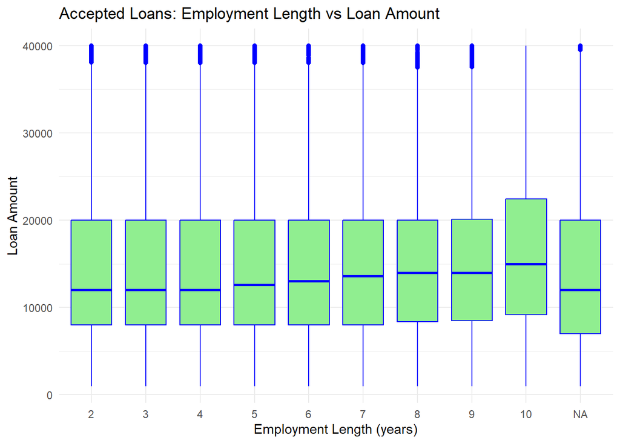

```r
# Boxplot for accepted loans: Employment Length vs Loan Amount
ggplot(accepted_loans, aes(x = as.factor(emp_length_cleaned), y = loan_amnt_cleaned)) +
  geom_boxplot(fill = "lightgreen", color = "blue") +
  ggtitle("Accepted Loans: Employment Length vs Loan Amount") +
  xlab("Employment Length (years)") +
  ylab("Loan Amount") +
  theme_minimal()
```

#Working on the rejected loan set, cleaning the outliers.

```r
# Calculate Q1, Q3, and IQR for amount requested
Q1 <- quantile(rejected_loans$amount_requested_cleaned, 0.25, na.rm = TRUE)
Q3 <- quantile(rejected_loans$amount_requested_cleaned, 0.75, na.rm = TRUE)
IQR <- Q3 - Q1

# Define lower and upper bound
lower_bound <- Q1 - 1.5 * IQR
upper_bound <- Q3 + 1.5 * IQR

# Filter out outliers
rejected_loans_filtered <- rejected_loans %>%
  filter(amount_requested_cleaned >= lower_bound & amount_requested_cleaned <= upper_bound)

# Check summary statistics of filtered data
summary(rejected_loans_filtered$amount_requested_cleaned)
```

```
##    Min. 1st Qu.  Median    Mean 3rd Qu.    Max.
##       0    4500   10000   12416   20000   43250
```

#creating boxplot for outliers exempted data

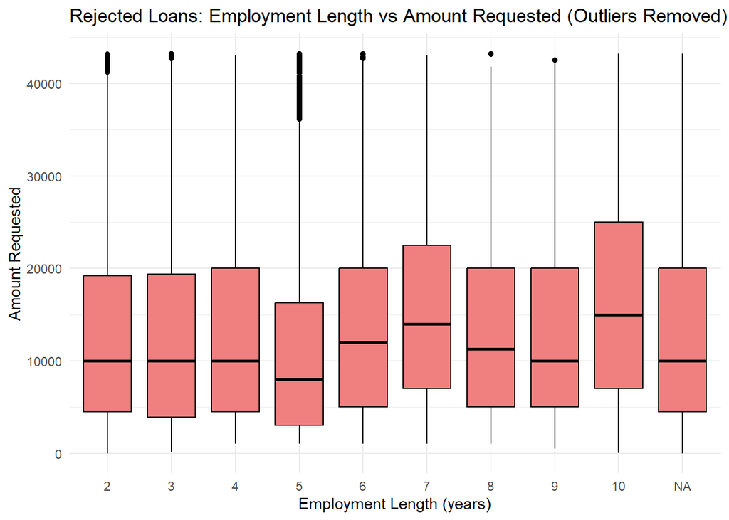

```r
# Boxplot without outliers
ggplot(rejected_loans_filtered, aes(x = as.factor(emp_length_cleaned), y = amount_requested_cleaned)) +
  geom_boxplot(fill = "lightcoral", color = "black") +
  ggtitle("Rejected Loans: Employment Length vs Amount Requested (Outliers Removed)") +
  xlab("Employment Length (years)") +
  ylab("Amount Requested") +
  theme_minimal()
```

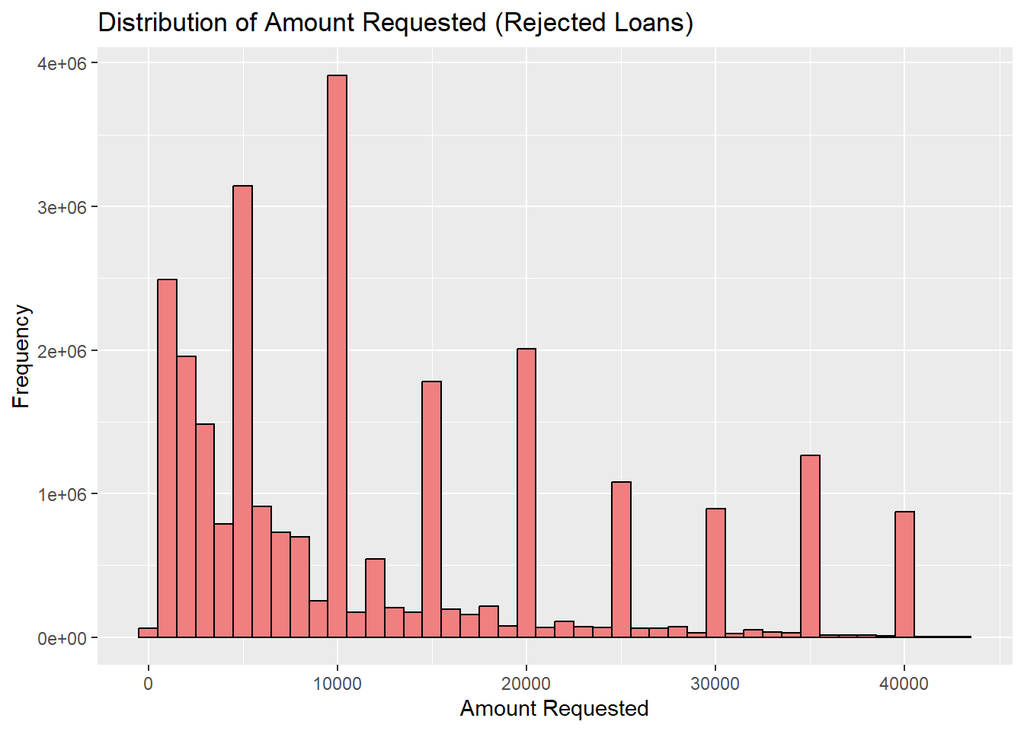

```r
ggplot(rejected_loans_filtered, aes(x = amount_requested_cleaned)) +
  geom_histogram(binwidth = 1000, fill = "lightcoral", color = "black") +
  ggtitle("Distribution of Amount Requested (Rejected Loans)") +
  xlab("Amount Requested") +
  ylab("Frequency")
```

#Distribution of Loan amount (Accepted loans)

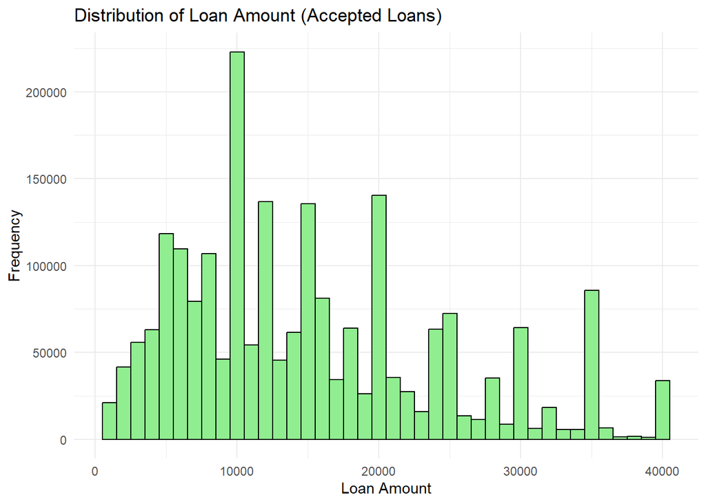

```r
# Plot the distribution of loan amounts for accepted loans
ggplot(accepted_loans, aes(x = loan_amnt_cleaned)) +
  geom_histogram(binwidth = 1000, fill = "lightgreen", color = "black") +
  ggtitle("Distribution of Loan Amount (Accepted Loans)") +
  xlab("Loan Amount") +
  ylab("Frequency") +
  theme_minimal()
```

#Employment length pie chart (rejected loans)

```r
# Filter employment lengths between 1 and 10 years
emp_length_filtered <- rejected_loans %>%
  filter(emp_length_cleaned >= 1 & emp_length_cleaned <= 10)

# Calculate the percentage of each employment length (1 to 10 years)
emp_length_counts <- table(emp_length_filtered$emp_length_cleaned)
emp_length_percentage <- prop.table(emp_length_counts) * 100

# Convert to a data frame for easy plotting
emp_length_df <- as.data.frame(emp_length_percentage)
colnames(emp_length_df) <- c("Employment_Length", "Percentage")

# Print the percentage table for reference
print(emp_length_df)
```

```
##   Employment_Length Percentage
## 1                 2   5.265014
## 2                 3   4.773367
## 3                 4   3.214956
## 4                 5  68.895998
## 5                 6   1.839308
## 6                 7   1.447074
## 7                 8   1.779776
## 8                 9   1.284662
## 9                10  11.499843
```

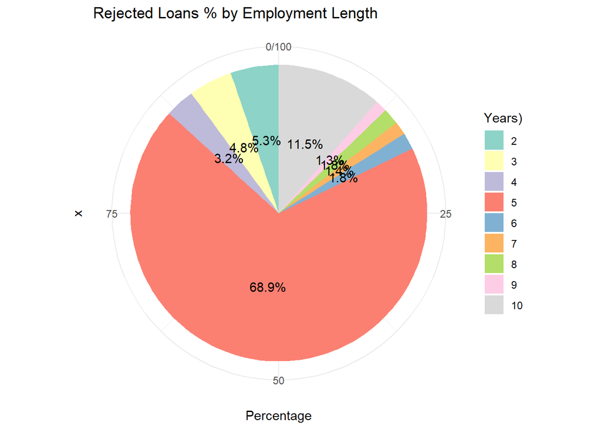

```r
# Plot the data using a pie chart
ggplot(emp_length_df, aes(x = "", y = Percentage, fill = factor(Employment_Length))) +
  geom_bar(stat = "identity", width = 1) +
  coord_polar("y", start = 0) +
  geom_text(aes(label = paste0(round(Percentage, 1), "%")), position = position_stack(vjust = 0.5)) +
  ggtitle("Rejected Loans % by Employment Length") +
  theme_minimal() +
  scale_fill_brewer(palette = "Set3") +  # Colorful palette for the pie chart
  labs(fill = "Years)")
```

#Employment length pie chart (accepted loans)

```r
# Filter employment lengths between 1 and 10 years for accepted loans
emp_length_filtered_accepted <- accepted_loans %>%
  filter(emp_length_cleaned >= 1 & emp_length_cleaned <= 10)

# Calculate the percentage of each employment length (1 to 10 years)
emp_length_counts_accepted <- table(emp_length_filtered_accepted$emp_length_cleaned)
emp_length_percentage_accepted <- prop.table(emp_length_counts_accepted) * 100

# Convert to a data frame for easy plotting
emp_length_df_accepted <- as.data.frame(emp_length_percentage_accepted)
colnames(emp_length_df_accepted) <- c("Employment_Length", "Percentage")

# Print the percentage table for reference
print(emp_length_df_accepted)
```

```
##   Employment_Length Percentage
## 1                 2  11.425828
## 2                 3  10.158142
## 3                 4   7.594007
## 4                 5   7.746975
## 5                 6   5.671866
## 6                 7   5.159512
## 7                 8   5.179061
## 8                 9   4.481905
## 9                10  42.582703
```

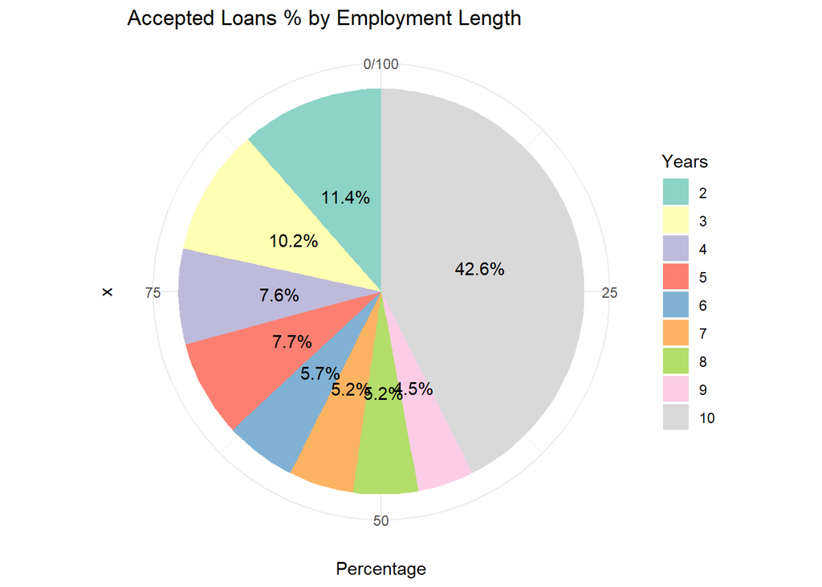

```r
# Plot the data using a pie chart
ggplot(emp_length_df_accepted, aes(x = "", y = Percentage, fill = factor(Employment_Length))) +
  geom_bar(stat = "identity", width = 1) +
  coord_polar("y", start = 0) +
  geom_text(aes(label = paste0(round(Percentage, 1), "%")), position = position_stack(vjust = 0.5)) +
  ggtitle("Accepted Loans % by Employment Length") +
  theme_minimal() +
  scale_fill_brewer(palette = "Set3") +  # Use a colorful palette for better visual appeal
  labs(fill = "Years")
```

#Cleaning data for statistical analysis

```r
# Ensure the columns are numeric for accepted loans
accepted_loans$emp_length_cleaned <- as.numeric(accepted_loans$emp_length_cleaned)
accepted_loans$dti_numeric <- as.numeric(accepted_loans$dti)
accepted_loans$loan_amnt_cleaned <- as.numeric(accepted_loans$loan_amnt)

# Ensure the columns are numeric for rejected loans
rejected_loans$emp_length_cleaned <- as.numeric(rejected_loans$emp_length_cleaned)
rejected_loans$Debt.To.Income.Ratio_numeric <- as.numeric(gsub("%", "", rejected_loans$Debt.To.Income.Ratio)) / 100
rejected_loans$amount_requested_cleaned <- as.numeric(rejected_loans$Amount.Requested)
```

#Accepted loan analysis Employment VS loan grade VS Annual income VS DTI

```r
# Load necessary libraries
library(ggplot2)
library(dplyr)

# 1. ANOVA: Employment Length vs Loan Grade
anova_grade <- aov(emp_length_cleaned ~ grade, data = accepted_loans)
anova_summary <- summary(anova_grade)

# 2. Pearson Correlation: Employment Length vs Annual Income
cor_emp_income <- cor.test(accepted_loans$emp_length_cleaned, accepted_loans$annual_inc, use = "complete.obs")

# 3. Pearson Correlation: Employment Length vs DTI
cor_emp_dti <- cor.test(accepted_loans$emp_length_cleaned, accepted_loans$dti_numeric, use = "complete.obs")

# Create a summary table for results
test_results <- data.frame(
  Test = c("ANOVA: Employment Length vs Loan Grade",
           "Correlation: Employment Length vs Annual Income",
           "Correlation: Employment Length vs DTI"),

  Statistic = c(anova_summary[[1]][["F value"]][1],
                cor_emp_income$estimate,
                cor_emp_dti$estimate),

  P_Value = c(anova_summary[[1]][["Pr(>F)"]][1],
              cor_emp_income$p.value,
              cor_emp_dti$p.value)
)

# Print the summary table
print(test_results)
```

```
##                                              Test   Statistic       P_Value
## 1          ANOVA: Employment Length vs Loan Grade 47.28389276  2.560811e-58
## 2 Correlation: Employment Length vs Annual Income  0.03487031  0.000000e+00
## 3           Correlation: Employment Length vs DTI  0.02426030 8.966811e-219
```

# Statistical analysis between employment length and Amount requested DTI Risk score (rejected)

```r
# Load necessary libraries
library(dplyr)
library(ggplot2)

# Data Preparation: Ensure all variables are numeric
rejected_loans$emp_length_cleaned <- as.numeric(rejected_loans$emp_length_cleaned)
rejected_loans$amount_requested_cleaned <- as.numeric(rejected_loans$Amount.Requested)
rejected_loans$Debt.To.Income.Ratio_numeric <- as.numeric(gsub("%", "", rejected_loans$Debt.To.Income.Ratio)) / 100
rejected_loans$Risk_Score <- as.numeric(rejected_loans$Risk_Score)

# Remove rows with missing values
rejected_loans_cleaned <- rejected_loans %>%
  filter(!is.na(emp_length_cleaned) &
         !is.na(amount_requested_cleaned) &
         !is.na(Debt.To.Income.Ratio_numeric) &
         !is.na(Risk_Score))

# 1. Pearson Correlation: Employment Length vs Amount Requested
cor_emp_amount <- cor.test(rejected_loans_cleaned$emp_length_cleaned, rejected_loans_cleaned$amount_requested_cleaned, use = "complete.obs")

# 2. Pearson Correlation: Employment Length vs DTI
cor_emp_dti <- cor.test(rejected_loans_cleaned$emp_length_cleaned, rejected_loans_cleaned$Debt.To.Income.Ratio_numeric, use = "complete.obs")

# 3. Linear Regression: Employment Length vs Risk Score
reg_emp_risk <- lm(Risk_Score ~ emp_length_cleaned, data = rejected_loans_cleaned)
summary_reg_emp_risk <- summary(reg_emp_risk)

# Prepare the results for a table output
test_results <- data.frame(
  Test = c("Correlation: Employment Length vs Amount Requested",
           "Correlation: Employment Length vs DTI",
           "Linear Regression: Employment Length vs Risk Score"),

  Statistic = c(round(cor_emp_amount$estimate, 2),
                round(cor_emp_dti$estimate, 2),
                round(summary_reg_emp_risk$coefficients[2, "t value"], 2)),

  P_Value = c(round(cor_emp_amount$p.value, 2),
              round(cor_emp_dti$p.value, 2),
              round(summary_reg_emp_risk$coefficients[2, "Pr(>|t|)"], 2))
)

# Print the results
print(test_results)
```

```
##                                                 Test Statistic P_Value
## 1 Correlation: Employment Length vs Amount Requested      0.12    0.00
## 2              Correlation: Employment Length vs DTI      0.00    0.39
## 3 Linear Regression: Employment Length vs Risk Score     74.87    0.00
```